# Implementing Random Forest and Other Ensemble Algorithms

Using Bank Loan dataset

Sophia Tang Hart

October 2021

# OBJECTIVE AND DATA DESCRIPTION

**Background:**

Banks loan out money to customers to finance a car, a house, pay for education, consolidate loans, etc. Borrowers agree to pay back the money with an interest on a monthly basis. Sometimes, due to unexpected circumstances, some borrowers are not able to pay back the money.

**Research Objectives:**

For the banks, it would be helpful to see what is the pattern in the customers to predict if a customer can pay back the loan, so the back knows who to lend out the money. I want to predict if any customer goes to a bank, should the bank loan out the money to the customer base on model learned from this dataset.

**Research Questions:**

1. What factors contribute/correlated most to bank loan status?
2. Can we predict if a borrower will be able to pay the debt in full?
3. What Machine Learning algorithms perform best in the prediction? (First Guess)
4. Optimize all (or the best) algorithms. With the fine tuned hyperparameters, what is the best prediction performance? Which algorithm?

**Dataset**

The dataset is taken from Kaggle (https://www.kaggle.com/zaurbegiev/my-dataset). There are over 100,000 rows and 19 columns (features) in this dataset. The predicted feature variable is Loan_Status, which is a categorical variable with value either “Fully Paid” or “Charged off”. Fully Paid means the borrower can pay back the debt, while charged off means the borrower is unlikely pay the bank after a substantial delinquent for a period of time. The remainder of the debt is sometimes collected by a third-party agency.

LoanID,

CustomerID,

Loan_Status,

Current_Loan_Amount,

Term,

Credit_Score,

Annual_Income,

Years_in_current_job,

Home_Ownership,

Purpose,

Monthly_Debt,

Years_of_Credit_History,

Months_since_last_delinquent,

Number_of_Open_Accounts,

Number_of_Credit_Problems,

Current_Credit_Balance,

Maximum_Open_Credit,

Bankruptcies,

Tax_Liens

# STEP 1: LOAD LIBRARIES AND DATA

```r
library(caret)
library(dplyr)
library(tidyverse)
library(mlbench)
library(gmodels)
# for multiple plots in one figure (ggarrange)
library(ggpubr)
library(ROSE)
# for method=ranger of Random Forest
library(ranger)
library(e1071)
# for gradient boosting
library(C50)
library(plyr)
library(gbm)
# for caretList
library(rpart)
library(caretEnsemble)
library(nnet)
library(pROC)
```

### Examing data

```r
# Clear memory
rm(list=ls())

# read in data
BankLoan_dataset <- read.csv("LoanStatus.csv")

# remove unrelevant fields
BankLoan_dataset <- subset(BankLoan_dataset, select=-c(LoanID, CustomerID))

# data structure
str(BankLoan_dataset)
```

```
## 'data.frame':    100000 obs. of  17 variables:
##  $ Loan_Status                 : chr  "Fully Paid" "Fully Paid" "Fully Paid" "Fully Paid" ...
##  $ Current_Loan_Amount         : int  445412 262328 99999999 347666 176220 206602 217646 648714 548746 215952 ...
##  $ Term                        : chr  "Short Term" "Short Term" "Short Term" "Long Term" ...
##  $ Credit_Score                : int  709 NA 741 721 NA 7290 730 NA 678 739 ...
##  $ Annual_Income               : int  1167493 NA 2231892 806949 NA 896857 1184194 NA 2559110 1454735 ...
##  $ Years_in_current_job        : chr  "8 years" "10+ years" "8 years" "3 years" ...
##  $ Home_Ownership              : chr  "Home Mortgage" "Home Mortgage" "Own Home" "Own Home" ...
##  $ Purpose                     : chr  "Home Improvements" "Debt Consolidation" "Debt Consolidation" "Debt Consolidation" ...
##  $ Monthly_Debt                : num  5215 33296 29201 8742 20640 ...
##  $ Years_of_Credit_History     : num  17.2 21.1 14.9 12 6.1 17.3 19.6 8.2 22.6 13.9 ...
##  $ Months_since_last_delinquent: int  NA 8 29 NA NA NA 10 8 33 NA ...
##  $ Number_of_Open_Accounts     : int  6 35 18 9 15 6 13 15 4 20 ...
##  $ Number_of_Credit_Problems   : int  1 0 1 0 0 0 1 0 0 0 ...
##  $ Current_Credit_Balance      : int  228190 229976 297996 256329 253460 215308 122170 193306 437171 669560 ...
##  $ Maximum_Open_Credit         : int  416746 850784 750090 386958 427174 272448 272052 864204 555038 1021460 ...
##  $ Bankruptcies                : int  1 0 0 0 0 0 1 0 0 0 ...
##  $ Tax_Liens                   : int  0 0 0 0 0 0 0 0 0 0 ...
```

```r
# data summary
summary(BankLoan_dataset)
```

```
##  Loan_Status        Current_Loan_Amount     Term            Credit_Score
##  Length:100000      Min.   :   10802    Length:100000      Min.   : 585
##  Class :character   1st Qu.:  179652    Class :character   1st Qu.: 705
##  Mode  :character   Median :  312246    Mode  :character   Median : 724
##                     Mean   :11760447                       Mean   :1076
##                     3rd Qu.:  524942                       3rd Qu.: 741
##                     Max.   :99999999                       Max.   :7510
##                                                            NA's   :19154
##  Annual_Income       Years_in_current_job Home_Ownership       Purpose
##  Min.   :    76627   Length:100000        Length:100000      Length:100000
##  1st Qu.:   848844   Class :character     Class :character   Class :character
##  Median :  1174162   Mode  :character     Mode  :character   Mode  :character
##  Mean   :  1378277
##  3rd Qu.:  1650663
##  Max.   :165557393
##  NA's   :19154
##   Monthly_Debt    Years_of_Credit_History Months_since_last_delinquent
##  Min.   :     0   Min.   : 3.6            Min.   :  0.0
##  1st Qu.: 10214   1st Qu.:13.5            1st Qu.: 16.0
##  Median : 16220   Median :16.9            Median : 32.0
##  Mean   : 18472   Mean   :18.2            Mean   : 34.9
##  3rd Qu.: 24012   3rd Qu.:21.7            3rd Qu.: 51.0
##  Max.   :435843   Max.   :70.5            Max.   :176.0
##                                           NA's   :53141
##  Number_of_Open_Accounts Number_of_Credit_Problems Current_Credit_Balance
##  Min.   : 0.00           Min.   : 0.0000           Min.   :       0
##  1st Qu.: 8.00           1st Qu.: 0.0000           1st Qu.:  112670
##  Median :10.00           Median : 0.0000           Median :  209817
##  Mean   :11.13           Mean   : 0.1683           Mean   :  294637
##  3rd Qu.:14.00           3rd Qu.: 0.0000           3rd Qu.:  367959
##  Max.   :76.00           Max.   :15.0000           Max.   :32878968
##
##  Maximum_Open_Credit  Bankruptcies      Tax_Liens
##  Min.   :0.000e+00   Min.   :0.0000   Min.   : 0.00000
##  1st Qu.:2.734e+05   1st Qu.:0.0000   1st Qu.: 0.00000
##  Median :4.679e+05   Median :0.0000   Median : 0.00000
##  Mean   :7.608e+05   Mean   :0.1177   Mean   : 0.02931
##  3rd Qu.:7.830e+05   3rd Qu.:0.0000   3rd Qu.: 0.00000
##  Max.   :1.540e+09   Max.   :7.0000   Max.   :15.00000
##  NA's   :2           NA's   :204      NA's   :10
```

# STEP 2: DATA PREPROCESSING

## a) Convert to numeric values

```r
BankLoan_dataset$Years_in_current_job = extract_numeric(BankLoan_dataset$Years_in_current_job)
```

```
## extract_numeric() is deprecated: please use readr::parse_number() instead
```

```r
BankLoan_dataset$Years_in_current_job <- as.numeric(BankLoan_dataset$Years_in_current_job)
```

## b) Convert Categorical Variables

## d) Remove Null

```r
# # identify outliers
# outliers <- boxplot(BankLoan_dataset$Annual_Income, plot=FALSE)$out
# # remove outliers
# BankLoan_dataset <- BankLoan_dataset[-which(BankLoan_dataset$Annual_Income %in% outliers), ]
#
```

We cannot remove outliers for individual feature one at a time, because after removing the outliers, some of the records are removing. The rows will be mismatch when we combine the features together. Therefore, we have to use the pipe function like below.

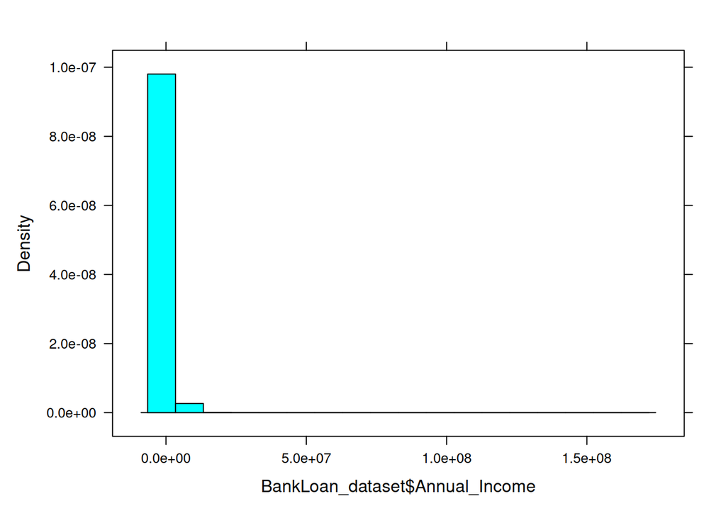

```r
# show outliers before removing them
histogram(BankLoan_dataset$Annual_Income)
```

```r
bankloan <- BankLoan_dataset %>%
  # convert string feature into categorical factors
  mutate_if(is.character, as.factor) %>%

  # remove the nulls
  drop_na() %>%

  ### Remove outliers
  # Annual_Income
  filter(between(Annual_Income,
                 quantile(Annual_Income, 0.25) - 1.5* IQR(Annual_Income),
                 quantile(Annual_Income, 0.75) + 1.5* IQR(Annual_Income))) %>%
  # Current_Loan_Amount
  filter(between(Current_Loan_Amount,
                 quantile(Current_Loan_Amount, 0.25) - 1.5* IQR(Current_Loan_Amount),
                 quantile(Current_Loan_Amount, 0.75) + 1.5* IQR(Current_Loan_Amount))) %>%
  # Credit_Score
  filter(between(Credit_Score,
                 quantile(Credit_Score, 0.25) - 1.5* IQR(Credit_Score),
                 quantile(Credit_Score, 0.75) + 1.5* IQR(Credit_Score))) %>%
  #Number_of_Credit_Problems (there is an outlier of 15)
  filter(between(Number_of_Credit_Problems,
                 quantile(Number_of_Credit_Problems, 0.25) - 1.5* IQR(Number_of_Credit_Problems),
                 4)) %>%
  # Monthly_Debt
  filter(between(Monthly_Debt,
               quantile(Monthly_Debt, 0.25) - 1.5* IQR(Monthly_Debt),
               quantile(Monthly_Debt, 0.75) + 1.5* IQR(Monthly_Debt))) %>%

  #remove null after filling outliers with NA
  drop_na()

str(bankloan)
```

```
## 'data.frame':    26463 obs. of  17 variables:
##  $ Loan_Status                 : Factor w/ 2 levels "Charged Off",..: 2 2 2 2 1 2 2 1 2 2 ...
##  $ Current_Loan_Amount         : int  217646 548746 234124 666204 317108 465410 449108 688468 129712 287980 ...
##  $ Term                        : Factor w/ 2 levels "Long Term","Short Term": 2 2 2 1 1 1 2 1 2 2 ...
##  $ Credit_Score                : int  730 678 727 723 687 688 718 682 723 737 ...
##  $ Annual_Income               : int  1184194 2559110 693234 1821967 1133274 1722654 1454507 1494616 1465698 1013954 ...
##  $ Years_in_current_job        : num  1 2 10 10 8 3 8 1 10 1 ...
##  $ Home_Ownership              : Factor w/ 4 levels "HaveMortgage",..: 2 4 4 2 4 4 2 4 3 2 ...
##  $ Purpose                     : Factor w/ 16 levels "Business Loan",..: 4 4 4 4 4 3 4 4 4 4 ...
##  $ Monthly_Debt                : num  10855 18660 14211 17612 9633 ...
##  $ Years_of_Credit_History     : num  19.6 22.6 24.7 22 17.4 22.3 28.8 16.6 19.4 18.6 ...
##  $ Months_since_last_delinquent: int  10 33 46 34 53 30 21 50 6 13 ...
##  $ Number_of_Open_Accounts     : int  13 4 10 15 4 7 14 8 34 11 ...
##  $ Number_of_Credit_Problems   : int  1 0 1 0 0 0 0 0 1 0 ...
##  $ Current_Credit_Balance      : int  122170 437171 28291 813694 60287 107559 193990 343995 45106 223117 ...
##  $ Maximum_Open_Credit         : int  272052 555038 107052 2004618 126940 488356 458414 843854 163218 489302 ...
##  $ Bankruptcies                : int  1 0 1 0 0 0 0 0 0 0 ...
##  $ Tax_Liens                   : int  0 0 0 0 0 0 0 0 0 0 ...
```

```r
summary(bankloan)
```

```
##       Loan_Status    Current_Loan_Amount         Term        Credit_Score
##  Charged Off: 4827   Min.   : 21450      Long Term : 7164   Min.   :647.0
##  Fully Paid :21636   1st Qu.:164296      Short Term:19299   1st Qu.:702.0
##                      Median :262416                         Median :719.0
##                      Mean   :295844                         Mean   :715.5
##                      3rd Qu.:399278                         3rd Qu.:734.0
##                      Max.   :789096                         Max.   :751.0
##
##  Annual_Income     Years_in_current_job       Home_Ownership
##  Min.   : 111245   Min.   : 1.000       HaveMortgage :   62
##  1st Qu.: 899783   1st Qu.: 3.000       Home Mortgage:13336
##  Median :1211611   Median : 7.000       Own Home     : 2333
##  Mean   :1296903   Mean   : 6.233       Rent         :10732
##  3rd Qu.:1608056   3rd Qu.:10.000
##  Max.   :2960447   Max.   :10.000
##
##                Purpose       Monthly_Debt   Years_of_Credit_History
##  Debt Consolidation:20651   Min.   :    0   Min.   : 3.80
##  other             : 1682   1st Qu.:10732   1st Qu.:14.40
##  Home Improvements : 1658   Median :16296   Median :17.50
##  Other             :  852   Mean   :17368   Mean   :18.84
##  Business Loan     :  375   3rd Qu.:23054   3rd Qu.:22.10
##  Medical Bills     :  323   Max.   :43110   Max.   :70.50
##  (Other)           :  922
##  Months_since_last_delinquent Number_of_Open_Accounts Number_of_Credit_Problems
##  Min.   :  0.00               Min.   : 2.00           Min.   :0.0000
##  1st Qu.: 16.00               1st Qu.: 8.00           1st Qu.:0.0000
##  Median : 32.00               Median :11.00           Median :0.0000
##  Mean   : 35.15               Mean   :11.27           Mean   :0.1814
##  3rd Qu.: 51.00               3rd Qu.:14.00           3rd Qu.:0.0000
##  Max.   :176.00               Max.   :48.00           Max.   :4.0000
##
##  Current_Credit_Balance Maximum_Open_Credit  Bankruptcies      Tax_Liens
##  Min.   :      0        Min.   :        0   Min.   :0.0000   Min.   :0.00000
##  1st Qu.:  96986        1st Qu.:   239063   1st Qu.:0.0000   1st Qu.:0.00000
##  Median : 178049        Median :   402050   Median :0.0000   Median :0.00000
##  Mean   : 236148        Mean   :   619018   Mean   :0.1191   Mean   :0.02955
##  3rd Qu.: 306764        3rd Qu.:   664334   3rd Qu.:0.0000   3rd Qu.:0.00000
##  Max.   :6317956        Max.   :798255370   Max.   :4.0000   Max.   :4.00000
##
```

```r
#check if there is null
is.null(bankloan)
```

```
## [1] FALSE
```

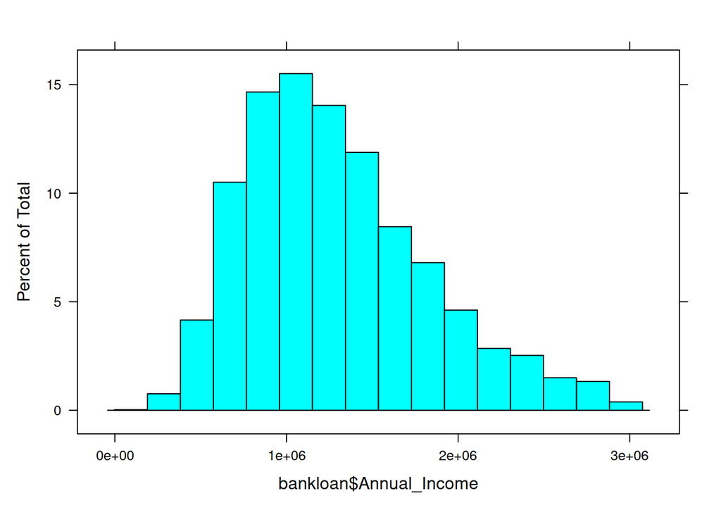

```r
# showing no outliers
histogram(bankloan$Annual_Income)
```

Histogram shows outliers are removed. Annual income is skewed right. After removing outliers and Null values, there are still 26,500 data left to work with.

# STEP 3: STATISTICAL SUMMARY

## a) Graphical Summary

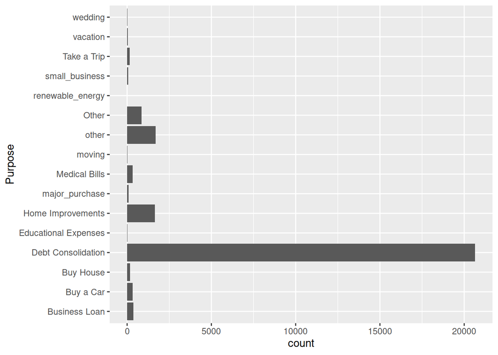

```r
# BAR graph for categorical variables

ggplot(bankloan, aes(x=Purpose)) +
  geom_bar() +
  coord_flip()
```

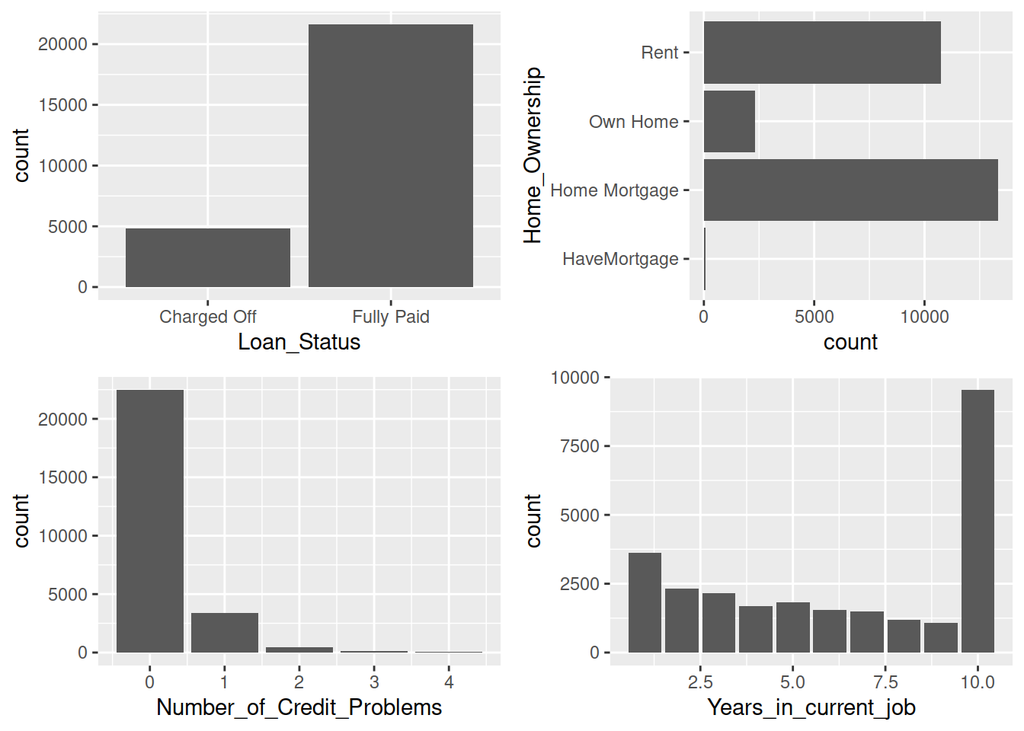

```r
gg_status <- ggplot(bankloan, aes(x=Loan_Status)) +
  geom_bar()

gg_home <- ggplot(bankloan, aes(x=Home_Ownership)) +
  geom_bar() +
  coord_flip()

gg_problem <- ggplot(bankloan, aes(x=Number_of_Credit_Problems)) +
  geom_bar()

gg_job <- ggplot(bankloan, aes(x=Years_in_current_job)) +
  geom_bar()

# arrange multiple plots in one figure
figure <- ggarrange(gg_status, gg_home, gg_problem, gg_job,
                    ncol = 2, nrow = 2,
                    legend="none")
figure
```

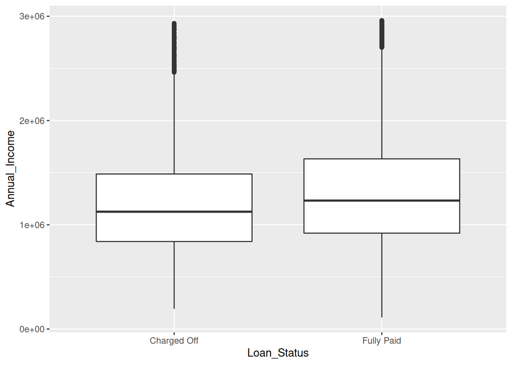

```r
# Boxplot for quantitative variables
ggplot(bankloan, aes(x=Loan_Status, y=Annual_Income)) +
  geom_boxplot()
```

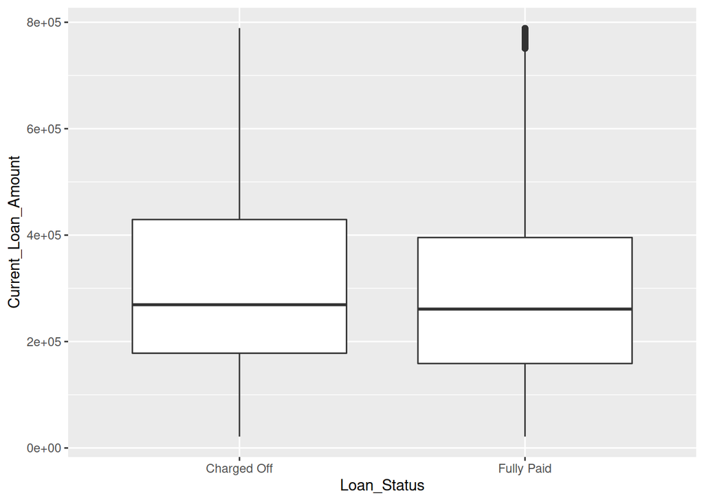

```r
ggplot(bankloan, aes(x=Loan_Status, y=Current_Loan_Amount)) +
  geom_boxplot()
```

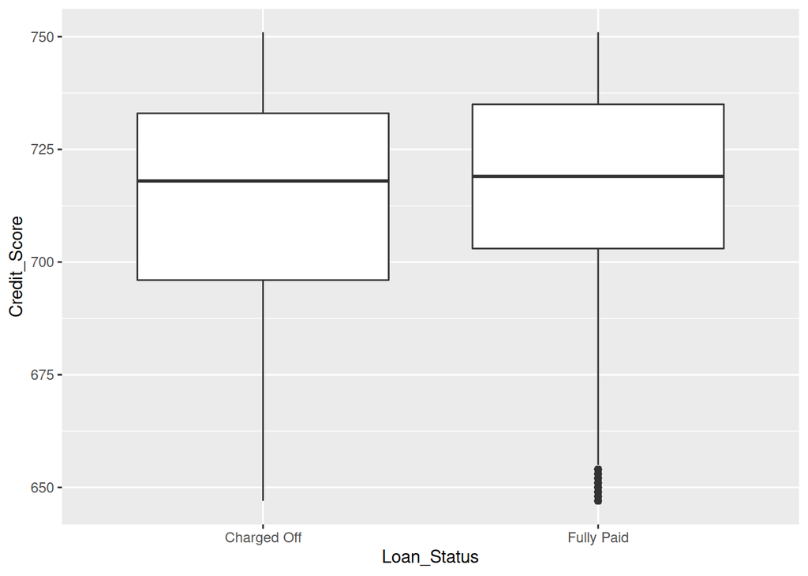

```r
ggplot(bankloan, aes(x=Loan_Status, y=Credit_Score)) +
  geom_boxplot()
```

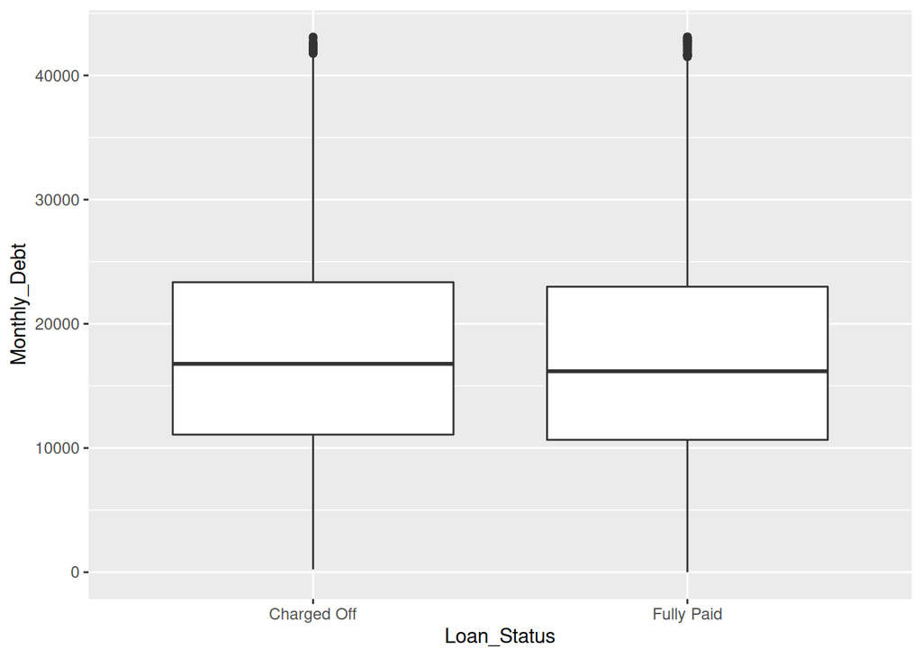

```r
ggplot(bankloan, aes(x=Loan_Status, y=Monthly_Debt)) +
  geom_boxplot()
```

From the Boxplots, comparing annual income, current loan amount, monthly debt and credit score, annual income seems to be the biggest difference between Fully Paid and Charged Off customers.

## b) Numerical Summary

```r
# proportion of Paid-fully and Charged-off
table(bankloan$Loan_Status)
```

```
##
## Charged Off  Fully Paid
##        4827       21636
```

```r
round(prop.table(table(bankloan$Loan_Status)) * 100, 1)
```

```
##
## Charged Off  Fully Paid
##        18.2        81.8
```

```r
# Average group by loan status
# Annual_Income is column5, credit score is column4
aggregate(bankloan[, 4:5], list(bankloan$Loan_Status), median)
```

```
##       Group.1 Credit_Score Annual_Income
## 1 Charged Off          718       1125408
## 2  Fully Paid          719       1232036
```

Numerical statistics shows Fully Paid is 81.8% of the total data. The median annual income for fully paid customers is 1.23M and 1.12M for charged off customers. Since the annual income is right-skew, median is used instead of mean.

# STEP 4: IMPLEMENTING RANDOM FOREST ALGORITHM

## a) Using All Numeric Feature Variables

```r
set.seed(9650)

# Divide data into train and test sets
indexTrain <- createDataPartition(y=bankloan$Loan_Status, p=0.75, list=FALSE)
training <- bankloan[indexTrain, ]
testing <- bankloan[-indexTrain, ]

# Number of variables randomly sampled as candidates at each split.
mtry = sqrt(ncol(training))

# setting the mtry value
tunegrid <- expand.grid(mtry=mtry)

# Cross Validation for parameter tuning
fitControl <- trainControl(method='repeatedcv', number=10, repeats=1)

# train the model
RFfit <- train(Loan_Status~., data=training, method='rf', ntree=100, tunegrid=tunegrid, trControl=fitControl, preProcess=c("center", "scale", "BoxCox"))

#print output
RFfit
```

```
## Random Forest
##
## 19848 samples
##    16 predictor
##     2 classes: 'Charged Off', 'Fully Paid'
##
## Pre-processing: centered (32), scaled (32), Box-Cox transformation (6)
## Resampling: Cross-Validated (10 fold, repeated 1 times)
## Summary of sample sizes: 17863, 17863, 17864, 17863, 17864, 17863, ...
## Resampling results across tuning parameters:
##
##   mtry  Accuracy   Kappa
##    2    0.8175635  0.00000000
##   17    0.8169588  0.03027096
##   32    0.8151450  0.03379003
##
## Accuracy was used to select the optimal model using the largest value.
## The final value used for the model was mtry = 2.
```

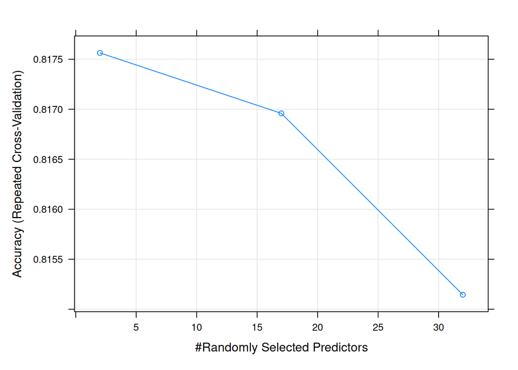

```r
plot(RFfit)
```

```r
# Prediction
RFpredict <- predict(RFfit, newdata=testing)

# confusion matrix to see accuracy and other parameter values
confusionMatrix(RFpredict, testing$Loan_Status)
```

```
## Confusion Matrix and Statistics
##
##              Reference
## Prediction    Charged Off Fully Paid
##   Charged Off           0          0
##   Fully Paid         1206       5409
##
##                Accuracy : 0.8177
##                  95% CI : (0.8082, 0.8269)
##     No Information Rate : 0.8177
##     P-Value [Acc > NIR] : 0.5077
##
##                   Kappa : 0
##
##  Mcnemar's Test P-Value : <2e-16
##
##             Sensitivity : 0.0000
##             Specificity : 1.0000
##          Pos Pred Value :    NaN
##          Neg Pred Value : 0.8177
##              Prevalence : 0.1823
##          Detection Rate : 0.0000
##    Detection Prevalence : 0.0000
##       Balanced Accuracy : 0.5000
##
##        'Positive' Class : Charged Off
##
```

```r
# compute accuracy by comparing prediction with actual classification
mean(RFpredict == testing$Loan_Status)
```

```
## [1] 0.8176871
```

Even though accuracy is 81.7%, from the confusion matrix, we see that all Charged Off is mispredicted as Fully Paid. This is because data is imbalance with 82% are Fully Paid. “BoxCox” method is applied to transform data into normal distribution, since by default z-score standardization works for normal distributed data.

## b) Random Search

```r
# Number of variables randomly sampled as candidates at each split.
mtry = sqrt(ncol(training))

# setting the mtry value
tunegrid <- expand.grid(mtry=mtry)

# Cross Validation for parameter tuning
fitControl <- trainControl(method='repeatedcv', number=10, search="random")

# train the model
RFfit <- train(Loan_Status~., data=training, method='rf', ntree=100, tunegrid=tunegrid, trControl=fitControl, preProcess=c("center", "scale", "BoxCox"), metric="Accuracy")

#print output
RFfit
```

```
## Random Forest
##
## 19848 samples
##    16 predictor
##     2 classes: 'Charged Off', 'Fully Paid'
##
## Pre-processing: centered (32), scaled (32), Box-Cox transformation (6)
## Resampling: Cross-Validated (10 fold, repeated 1 times)
## Summary of sample sizes: 17863, 17863, 17863, 17863, 17863, 17864, ...
## Resampling results across tuning parameters:
##
##   mtry  Accuracy   Kappa
##    4    0.8176643  0.001252188
##   20    0.8165055  0.027787755
##   28    0.8162537  0.037280678
##
## Accuracy was used to select the optimal model using the largest value.
## The final value used for the model was mtry = 4.
```

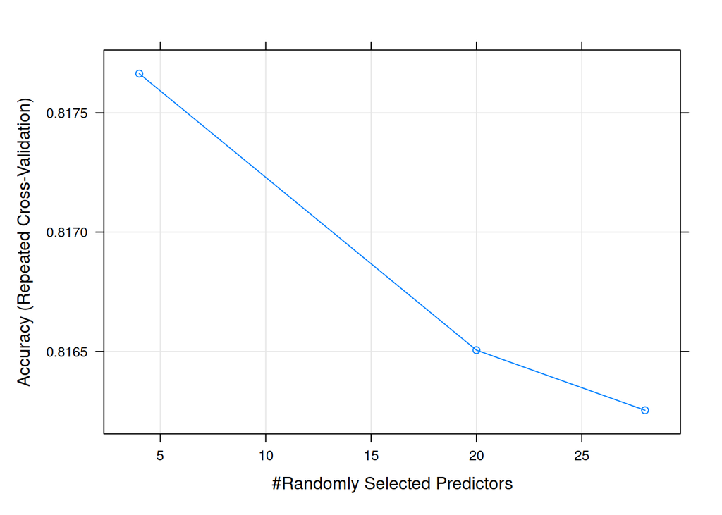

```r
plot(RFfit)
```

```r
# Prediction
RFpredict <- predict(RFfit, newdata=testing)

# confusion matrix to see accuracy and other parameter values
confusionMatrix(RFpredict, testing$Loan_Status)
```

```
## Confusion Matrix and Statistics
##
##              Reference
## Prediction    Charged Off Fully Paid
##   Charged Off           4          4
##   Fully Paid         1202       5405
##
##                Accuracy : 0.8177
##                  95% CI : (0.8082, 0.8269)
##     No Information Rate : 0.8177
##     P-Value [Acc > NIR] : 0.5077
##
##                   Kappa : 0.0042
##
##  Mcnemar's Test P-Value : <2e-16
##
##             Sensitivity : 0.0033167
##             Specificity : 0.9992605
##          Pos Pred Value : 0.5000000
##          Neg Pred Value : 0.8180717
##              Prevalence : 0.1823129
##          Detection Rate : 0.0006047
##    Detection Prevalence : 0.0012094
##       Balanced Accuracy : 0.5012886
##
##        'Positive' Class : Charged Off
##
```

```r
# compute accuracy by comparing prediction with actual classification
mean(RFpredict == testing$Loan_Status)
```

```
## [1] 0.8176871
```

Random Search also gives poor results.

## c) Different Version of Random Forest

```r
# Number of variables randomly sampled as candidates at each split.
mtry = sqrt(ncol(training))

# setting the mtry value
tunegrid <- expand.grid(mtry=mtry)

# Cross Validation for parameter tuning
fitControl <- trainControl(method='repeatedcv', number=10, repeats=1)

# train the model
RFfit5 <- train(Loan_Status~., data=training, method='ranger', trControl=fitControl, preProcess=c("center", "scale", "BoxCox"))

#print output
RFfit
```

```
## Random Forest
##
## 19848 samples
##    16 predictor
##     2 classes: 'Charged Off', 'Fully Paid'
##
## Pre-processing: centered (32), scaled (32), Box-Cox transformation (6)
## Resampling: Cross-Validated (10 fold, repeated 1 times)
## Summary of sample sizes: 17863, 17863, 17863, 17863, 17863, 17864, ...
## Resampling results across tuning parameters:
##
##   mtry  Accuracy   Kappa
##    4    0.8176643  0.001252188
##   20    0.8165055  0.027787755
##   28    0.8162537  0.037280678
##
## Accuracy was used to select the optimal model using the largest value.
## The final value used for the model was mtry = 4.
```

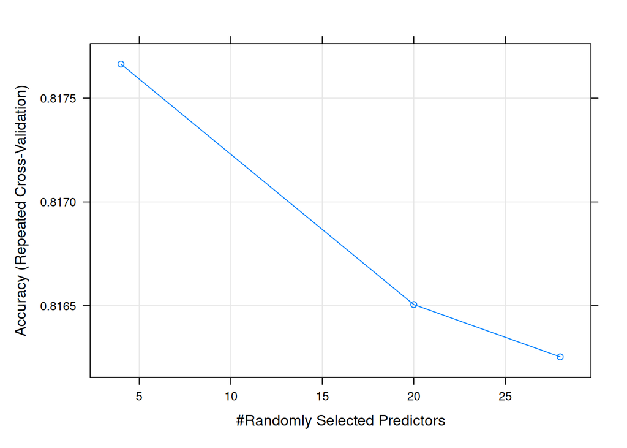

```r
plot(RFfit)
```

```r
# Prediction
RFpredict <- predict(RFfit, newdata=testing)

# confusion matrix to see accuracy and other parameter values
confusionMatrix(RFpredict, testing$Loan_Status)
```

```
## Confusion Matrix and Statistics
##
##              Reference
## Prediction    Charged Off Fully Paid
##   Charged Off           4          4
##   Fully Paid         1202       5405
##
##                Accuracy : 0.8177
##                  95% CI : (0.8082, 0.8269)
##     No Information Rate : 0.8177
##     P-Value [Acc > NIR] : 0.5077
##
##                   Kappa : 0.0042
##
##  Mcnemar's Test P-Value : <2e-16
##
##             Sensitivity : 0.0033167
##             Specificity : 0.9992605
##          Pos Pred Value : 0.5000000
##          Neg Pred Value : 0.8180717
##              Prevalence : 0.1823129
##          Detection Rate : 0.0006047
##    Detection Prevalence : 0.0012094
##       Balanced Accuracy : 0.5012886
##
##        'Positive' Class : Charged Off
##
```

```r
# compute accuracy by comparing prediction with actual classification
mean(RFpredict == testing$Loan_Status)
```

```
## [1] 0.8176871
```

The ranger version of Random Forest still gives poor results.

# STEP 5: PERFORMANCE IMPROVEMENT

My data are imbalanced, 81% is “fully Paid”. This is the reason most “Charge Off” class is wrongly predicted as “Fully Paid”. However, sensitivity = 0 from previous two models. This is very poor.

## a) Balancing Data by Downsampling

```r
set.seed(9650)

# Divide data into train and test sets
indexTrain <- createDataPartition(y=bankloan$Loan_Status, p=0.75, list=FALSE)
training <- bankloan[indexTrain, ]
testing <- bankloan[-indexTrain, ]

table(training$Loan_Status)
```

```
##
## Charged Off  Fully Paid
##        3621       16227
```

```r
# Downsampling to balance data
down_train <- downSample(x=training[, -ncol(training)], y=training$Loan_Status)
down_test <- downSample(x=testing[, -ncol(testing)], y=testing$Loan_Status)

table(down_train$Loan_Status)
```

```
##
## Charged Off  Fully Paid
##        3621        3621
```

```r
table(down_test$Loan_Status)
```

```
##
## Charged Off  Fully Paid
##        1206        1206
```

```r
# Number of variables randomly sampled as candidates at each split.
mtry = sqrt(ncol(training))

# setting the mtry value
tunegrid <- expand.grid(mtry=mtry)

# Cross Validation for parameter tuning
fitControl <- trainControl(method='repeatedcv', number=10, repeats=1)

# train the model
RFfit_down <- train(Loan_Status~., data=down_train, method='rf', ntree=100, tunegrid=tunegrid, trControl=fitControl, preProcess=c("center", "scale", "BoxCox"))

#print output
RFfit_down
```

```
## Random Forest
##
## 7242 samples
##   16 predictor
##    2 classes: 'Charged Off', 'Fully Paid'
##
## Pre-processing: centered (32), scaled (32), Box-Cox transformation (6)
## Resampling: Cross-Validated (10 fold, repeated 1 times)
## Summary of sample sizes: 6517, 6518, 6518, 6518, 6518, 6518, ...
## Resampling results across tuning parameters:
##
##   mtry  Accuracy   Kappa
##    2    0.9987569  0.9975138
##   17    1.0000000  1.0000000
##   32    1.0000000  1.0000000
##
## Accuracy was used to select the optimal model using the largest value.
## The final value used for the model was mtry = 17.
```

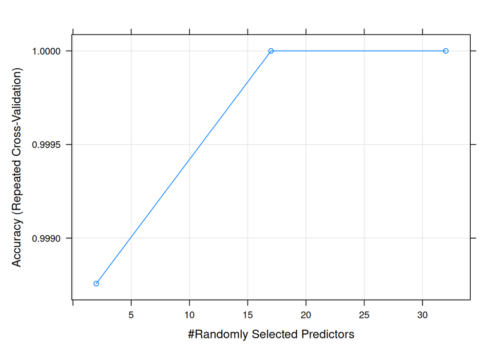

```r
plot(RFfit_down)
```

```r
# Prediction
RFpredict_down <- predict(RFfit_down, newdata=down_test)

# confusion matrix to see accuracy and other parameter values
confusionMatrix(RFpredict_down, down_test$Loan_Status)
```

```
## Confusion Matrix and Statistics
##
##              Reference
## Prediction    Charged Off Fully Paid
##   Charged Off        1206          0
##   Fully Paid            0       1206
##
##                Accuracy : 1
##                  95% CI : (0.9985, 1)
##     No Information Rate : 0.5
##     P-Value [Acc > NIR] : < 2.2e-16
##
##                   Kappa : 1
##
##  Mcnemar's Test P-Value : NA
##
##             Sensitivity : 1.0
##             Specificity : 1.0
##          Pos Pred Value : 1.0
##          Neg Pred Value : 1.0
##              Prevalence : 0.5
##          Detection Rate : 0.5
##    Detection Prevalence : 0.5
##       Balanced Accuracy : 1.0
##
##        'Positive' Class : Charged Off
##
```

```r
# compute accuracy by comparing prediction with actual classification
mean(RFpredict_down == down_test$Loan_Status)
```

```
## [1] 1
```

Balancing data by downsampling improves performance to 100%. There are 1200 test samples in each class. It’s remarkable that all 2400 test samples are classified correctly!

## b) Different Version of Random Forest

```r
set.seed(9650)
# Divide data into train and test sets
indexTrain <- createDataPartition(y=bankloan$Loan_Status, p=0.75, list=FALSE)
training <- bankloan[indexTrain, ]
testing <- bankloan[-indexTrain, ]

# Downsampling to balance data
down_train <- downSample(x=training[, -ncol(training)],
                         y=training$Loan_Status)
down_test <- downSample(x=testing[, -ncol(testing)],
                         y=testing$Loan_Status)

# Cross Validation for parameter tuning
fitControl <- trainControl(method='repeatedcv', number=10, repeats=1)

# train the model
RFfit <- train(Loan_Status~., data=training, method='ranger', trControl=fitControl, preProcess=c("center", "scale", "BoxCox"))

#print output
RFfit
```

```
## Random Forest
##
## 19848 samples
##    16 predictor
##     2 classes: 'Charged Off', 'Fully Paid'
##
## Pre-processing: centered (32), scaled (32), Box-Cox transformation (6)
## Resampling: Cross-Validated (10 fold, repeated 1 times)
## Summary of sample sizes: 17863, 17863, 17863, 17863, 17864, 17863, ...
## Resampling results across tuning parameters:
##
##   mtry  splitrule   Accuracy   Kappa
##    2    gini        0.8175635  0.00000000
##    2    extratrees  0.8175635  0.00000000
##   17    gini        0.8172108  0.01922263
##   17    extratrees  0.8182185  0.01752149
##   32    gini        0.8168078  0.03135357
##   32    extratrees  0.8175634  0.02026831
##
## Tuning parameter 'min.node.size' was held constant at a value of 1
## Accuracy was used to select the optimal model using the largest value.
## The final values used for the model were mtry = 17, splitrule = extratrees
##  and min.node.size = 1.
```

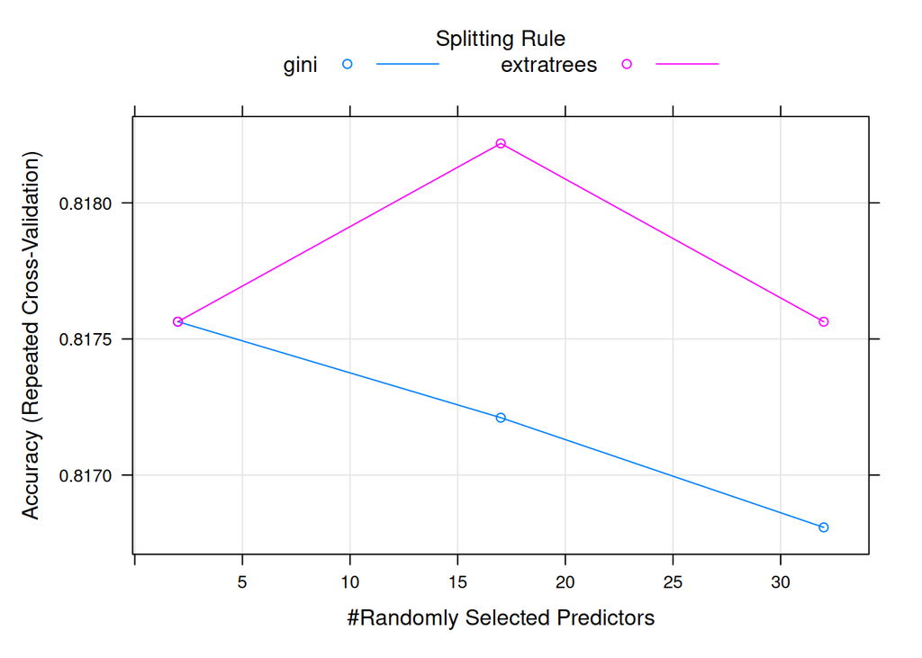

```r
plot(RFfit)
```

```r
# Prediction
RFpredict <- predict(RFfit, newdata=testing)

# confusion matrix to see accuracy and other parameter values
confusionMatrix(RFpredict, testing$Loan_Status)
```

```
## Confusion Matrix and Statistics
##
##              Reference
## Prediction    Charged Off Fully Paid
##   Charged Off          14         19
##   Fully Paid         1192       5390
##
##                Accuracy : 0.8169
##                  95% CI : (0.8074, 0.8262)
##     No Information Rate : 0.8177
##     P-Value [Acc > NIR] : 0.5708
##
##                   Kappa : 0.013
##
##  Mcnemar's Test P-Value : <2e-16
##
##             Sensitivity : 0.011609
##             Specificity : 0.996487
##          Pos Pred Value : 0.424242
##          Neg Pred Value : 0.818900
##              Prevalence : 0.182313
##          Detection Rate : 0.002116
##    Detection Prevalence : 0.004989
##       Balanced Accuracy : 0.504048
##
##        'Positive' Class : Charged Off
##
```

```r
# compute accuracy by comparing prediction with actual classification
mean(RFpredict == testing$Loan_Status)
```

```
## [1] 0.8169312
```

The ‘ranger’ version of Random Forest does not give as good results as ‘rf’

# STEP 6: TUNING HYPERPARAMETERS OF RANDOM FOREST

## a) Grid for mtry

```r
set.seed(9650)

# Number of variables randomly sampled as candidates at each split.
# setting the mtry grid
tunegrid <- expand.grid(.mtry=c(1:10))

# Cross Validation for parameter tuning
fitControl <- trainControl(method='repeatedcv', number=10, repeats=1)

# train the model
RFfit_mtry <- train(Loan_Status~., data=down_train, method='rf', ntree=100, tunegrid=tunegrid, trControl=fitControl, preProcess=c("center", "scale", "BoxCox"))

#print output
RFfit_mtry
```

```
## Random Forest
##
## 7242 samples
##   16 predictor
##    2 classes: 'Charged Off', 'Fully Paid'
##
## Pre-processing: centered (32), scaled (32), Box-Cox transformation (6)
## Resampling: Cross-Validated (10 fold, repeated 1 times)
## Summary of sample sizes: 6518, 6518, 6518, 6518, 6518, 6517, ...
## Resampling results across tuning parameters:
##
##   mtry  Accuracy   Kappa
##    2    0.9991717  0.9983433
##   17    1.0000000  1.0000000
##   32    1.0000000  1.0000000
##
## Accuracy was used to select the optimal model using the largest value.
## The final value used for the model was mtry = 17.
```

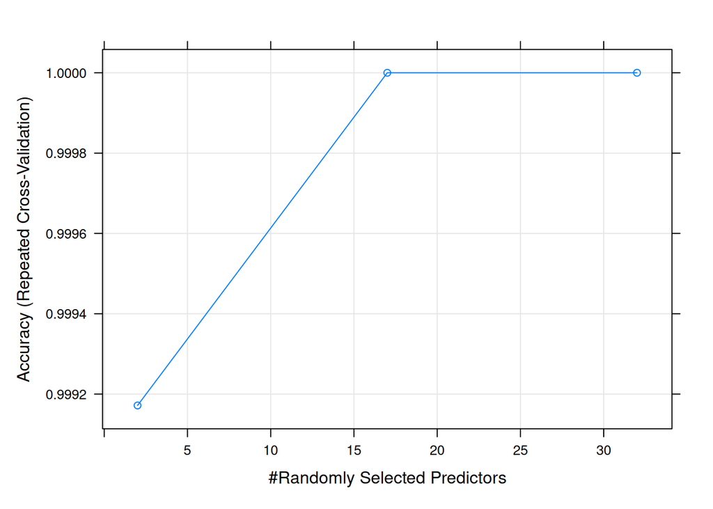

```r
plot(RFfit_mtry)
```

```r
# Prediction
RFpredict_mtry <- predict(RFfit_mtry, newdata=down_test)

# confusion matrix to see accuracy and other parameter values
confusionMatrix(RFpredict_mtry, down_test$Loan_Status)
```

```
## Confusion Matrix and Statistics
##
##              Reference
## Prediction    Charged Off Fully Paid
##   Charged Off        1206          0
##   Fully Paid            0       1206
##
##                Accuracy : 1
##                  95% CI : (0.9985, 1)
##     No Information Rate : 0.5
##     P-Value [Acc > NIR] : < 2.2e-16
##
##                   Kappa : 1
##
##  Mcnemar's Test P-Value : NA
##
##             Sensitivity : 1.0
##             Specificity : 1.0
##          Pos Pred Value : 1.0
##          Neg Pred Value : 1.0
##              Prevalence : 0.5
##          Detection Rate : 0.5
##    Detection Prevalence : 0.5
##       Balanced Accuracy : 1.0
##
##        'Positive' Class : Charged Off
##
```

```r
# compute accuracy by comparing prediction with actual classification
mean(RFpredict_mtry == down_test$Loan_Status)
```

```
## [1] 1
```

The grid for mtry shows 100% accuracy for most values. mtry=2 gives slightly less great performance.

## b) Trying Different ntree

```r
set.seed(9650)

# Number of variables randomly sampled as candidates at each split.
# setting the mtry grid
tunegrid <- expand.grid(.mtry=sqrt(ncol(down_train)))

modellist <- list()
# Cross Validation for parameter tuning
fitControl <- trainControl(method='repeatedcv', number=10, repeats=1, search = 'grid')

# train the model
# try different number of trees
for (ntree in c(500, 1000, 2000)) {
  set.seed(9650)
  RFfit_ntree <- train(Loan_Status~., data=down_train, method='rf', ntree=ntree, tunegrid=tunegrid, trControl=fitControl, preProcess=c("center", "scale", "BoxCox"))
  key <- toString(ntree)
  modellist[[key]] <- RFfit_ntree
}

#print output
results <- resamples(modellist)
summary(results)
```

```
##
## Call:
## summary.resamples(object = results)
##
## Models: 500, 1000, 2000
## Number of resamples: 10
##
## Accuracy
##      Min. 1st Qu. Median Mean 3rd Qu. Max. NA's
## 500     1       1      1    1       1    1    0
## 1000    1       1      1    1       1    1    0
## 2000    1       1      1    1       1    1    0
##
## Kappa
##      Min. 1st Qu. Median Mean 3rd Qu. Max. NA's
## 500     1       1      1    1       1    1    0
## 1000    1       1      1    1       1    1    0
## 2000    1       1      1    1       1    1    0
```

[figure not shown]

```r
dotplot(results)
```

```r
# Prediction
RFpredict_ntree <- predict(modellist, down_test)
pred <- RFpredict_ntree$`1000`
# confusion matrix to see accuracy and other parameter values
confusionMatrix(as.factor(pred), as.factor(down_test$Loan_Status))
```

```
## Confusion Matrix and Statistics
##
##              Reference
## Prediction    Charged Off Fully Paid
##   Charged Off        1206          0
##   Fully Paid            0       1206
##
##                Accuracy : 1
##                  95% CI : (0.9985, 1)
##     No Information Rate : 0.5
##     P-Value [Acc > NIR] : < 2.2e-16
##
##                   Kappa : 1
##
##  Mcnemar's Test P-Value : NA
##
##             Sensitivity : 1.0
##             Specificity : 1.0
##          Pos Pred Value : 1.0
##          Neg Pred Value : 1.0
##              Prevalence : 0.5
##          Detection Rate : 0.5
##    Detection Prevalence : 0.5
##       Balanced Accuracy : 1.0
##
##        'Positive' Class : Charged Off
##
```

Again, accuracy is 100% with different values of ntress.

# STEP 7: GRADIENT BOOSTING

```r
set.seed(9650)
# Divide data into train and test sets
indexTrain <- createDataPartition(y=bankloan$Loan_Status, p=0.75, list=FALSE)
training <- bankloan[indexTrain, ]
testing <- bankloan[-indexTrain, ]

# Cross Validation for parameter tuning
control <- trainControl(method='repeatedcv', number=10, repeats=1, search = 'random')
# C5.0
fit.c50 <- train(Loan_Status~., data=down_train, method='C5.0', trControl=control, preProcess=c("center", "scale", "BoxCox"))
# Gradient Boosting Method
set.seed(9650)
fit.gbm <- train(Loan_Status~., data=down_train, method='gbm', trControl=control, preProcess=c("center", "scale", "BoxCox"), verbose=FALSE)
# summarize results
boosting_results <- resamples(list(c5.0=fit.c50, gbm=fit.gbm))
summary(boosting_results)
```

```
##
## Call:
## summary.resamples(object = boosting_results)
##
## Models: c5.0, gbm
## Number of resamples: 10
##
## Accuracy
##      Min. 1st Qu. Median Mean 3rd Qu. Max. NA's
## c5.0    1       1      1    1       1    1    0
## gbm     1       1      1    1       1    1    0
##
## Kappa
##      Min. 1st Qu. Median Mean 3rd Qu. Max. NA's
## c5.0    1       1      1    1       1    1    0
## gbm     1       1      1    1       1    1    0
```

[figure not shown]

```r
dotplot(boosting_results)
```

```r
# prediction for C5.0
predictions <- predict(fit.c50, down_test)
confusionMatrix(predictions, down_test$Loan_Status)
```

```
## Confusion Matrix and Statistics
##
##              Reference
## Prediction    Charged Off Fully Paid
##   Charged Off        1206          0
##   Fully Paid            0       1206
##
##                Accuracy : 1
##                  95% CI : (0.9985, 1)
##     No Information Rate : 0.5
##     P-Value [Acc > NIR] : < 2.2e-16
##
##                   Kappa : 1
##
##  Mcnemar's Test P-Value : NA
##
##             Sensitivity : 1.0
##             Specificity : 1.0
##          Pos Pred Value : 1.0
##          Neg Pred Value : 1.0
##              Prevalence : 0.5
##          Detection Rate : 0.5
##    Detection Prevalence : 0.5
##       Balanced Accuracy : 1.0
##
##        'Positive' Class : Charged Off
##
```

```r
# prediction for gbm
predictions <- predict(fit.gbm, down_test)
confusionMatrix(predictions, down_test$Loan_Status)
```

```
## Confusion Matrix and Statistics
##
##              Reference
## Prediction    Charged Off Fully Paid
##   Charged Off        1206          0
##   Fully Paid            0       1206
##
##                Accuracy : 1
##                  95% CI : (0.9985, 1)
##     No Information Rate : 0.5
##     P-Value [Acc > NIR] : < 2.2e-16
##
##                   Kappa : 1
##
##  Mcnemar's Test P-Value : NA
##
##             Sensitivity : 1.0
##             Specificity : 1.0
##          Pos Pred Value : 1.0
##          Neg Pred Value : 1.0
##              Prevalence : 0.5
##          Detection Rate : 0.5
##    Detection Prevalence : 0.5
##       Balanced Accuracy : 1.0
##
##        'Positive' Class : Charged Off
##
```

Both versions of Gradient Boosting (the original model of caret–C5.0 and gbm) give also 100% accuracy.

# STEP 8: ENSEMBLE IMPLEMENTATION OF MULTIPLE ALGORITHMS

For the following algorithm, I’ll use 2000 samples instead of the entire 26000 because large data slows down run time.

## a) caretList

caretList is a flexible function for fitting many different caret models, with the same resampling parameters, to the same dataset.

```r
library(caret)
library(glmnet)
library(xgboost)
library(randomForest)

# Fitting a Single Model through Caret

library(ISLR)
library(caret)
library(readxl)
library(pROC)
library(lattice)
library(ggplot2)
library(dplyr)
library(e1071)
library(corrplot)
#library(kknn)
library(ggplot2)
library(multiROC)
library(MLeval)
library(AppliedPredictiveModeling)
library(corrplot)
library(Hmisc)
library(dplyr)
library(quantmod)

library(nnet)
library(caret)
library(NeuralNetTools)

library(mlbench)
library(caretEnsemble)
library(ranger)
library(mboost)
library(kernlab)

set.seed(9650)

# Data is very large 26,400 reports. So take out a subset to save time on running
sub_bankloan <- bankloan[1:2000, ]

# Need to convert to levels
levels(sub_bankloan$Loan_Status) <- c('first_class', 'second_class')
#bankloan$Loan_Status <- as.factor(bankloan$Loan_Status)

# Divide data into train and test sets
indexTrain <- createDataPartition(y=sub_bankloan$Loan_Status, p=0.75, list=FALSE)
training <- sub_bankloan[indexTrain, ]
testing <- sub_bankloan[-indexTrain, ]

# Downsampling to balance data
down_train <- downSample(x=training[, -ncol(training)], y=training$Loan_Status)
down_test <- downSample(x=testing[, -ncol(testing)], y=testing$Loan_Status)
typeof(down_train$Loan_Status)
```

```
## [1] "integer"
```

```r
# set parameter tunning
control <- trainControl(method='repeatedcv', number=10, repeats=1, search='grid', savePredictions = 'final', index=createResample(down_train$Loan_Status, 10), summaryFunction = twoClassSummary, classProbs = TRUE, verboseIter = FALSE)

# List of algorithms to use in ensemble
# glm (Generalized Linear Model), gbm, glmboost are Gradient Boosting methods, nnet is Neural Network. treebag is Bagged CART
# glmbost cause program stopping
alg_list <- c('rf', 'glm', 'gbm', 'nnet', 'treebag', 'svmLinear')

# caretList is a flexible function for fitting many different caret models, with the same resampling parameters, to the same dataset.
multi_mod <- caretList(Loan_Status~., data=down_train, trControl=control, methodList=alg_list, metric='ROC')
```

[output not shown]

```r
results <- resamples(multi_mod)
summary(results)
```

```
##
## Call:
## summary.resamples(object = results)
##
## Models: rf, glm, gbm, nnet, treebag, svmLinear
## Number of resamples: 10
##
## ROC
##                Min.   1st Qu.    Median      Mean   3rd Qu.      Max. NA's
## rf        1.0000000 1.0000000 1.0000000 1.0000000 1.0000000 1.0000000    0
## glm       1.0000000 1.0000000 1.0000000 1.0000000 1.0000000 1.0000000    0
## gbm       1.0000000 1.0000000 1.0000000 1.0000000 1.0000000 1.0000000    0
## nnet      0.4778801 0.4903299 0.5041921 0.5147314 0.5335930 0.5688095    0
## treebag   1.0000000 1.0000000 1.0000000 1.0000000 1.0000000 1.0000000    0
## svmLinear 0.4623268 0.4909715 0.5121956 0.5117996 0.5330237 0.5604804    6
##
## Sens
##                Min.   1st Qu.    Median      Mean   3rd Qu.      Max. NA's
## rf        1.0000000 1.0000000 1.0000000 1.0000000 1.0000000 1.0000000    0
## glm       1.0000000 1.0000000 1.0000000 1.0000000 1.0000000 1.0000000    0
## gbm       1.0000000 1.0000000 1.0000000 1.0000000 1.0000000 1.0000000    0
## nnet      0.1588785 0.2658114 0.4459459 0.5250285 0.7532026 1.0000000    0
## treebag   1.0000000 1.0000000 1.0000000 1.0000000 1.0000000 1.0000000    0
## svmLinear 0.1284404 0.1850227 0.2415814 0.3768591 0.4334178 0.8958333    6
##
## Spec
##               Min.   1st Qu.    Median      Mean   3rd Qu.      Max. NA's
## rf        1.000000 1.0000000 1.0000000 1.0000000 1.0000000 1.0000000    0
## glm       1.000000 1.0000000 1.0000000 1.0000000 1.0000000 1.0000000    0
## gbm       1.000000 1.0000000 1.0000000 1.0000000 1.0000000 1.0000000    0
## nnet      0.000000 0.2259878 0.6220238 0.4979571 0.7696839 0.8900000    0
## treebag   1.000000 1.0000000 1.0000000 1.0000000 1.0000000 1.0000000    0
## svmLinear 0.122449 0.5786892 0.7643208 0.6292675 0.8148991 0.8659794    6
```

All the tree base algorithms (rf, glm, gbm, treebag) give 100% ROC, 100% sensitivity and 100% specificity. Neural Network and SVM give less great performance. For some reason, glmboost cause my program to stop, so it’s not included in the execution.

## b) caretStack

Combine several predictive models via stacking. Find a good linear combination of several classification or regreesion models, using either linear regression, elastic net regression, or greedy optimization.

```r
set.seed(9650)

# Data is very large 26,400 reports. So take out a subset to save time on running
sub_bankloan <- bankloan[1:1000, ]

# Need to convert to levels
levels(sub_bankloan$Loan_Status) <- c('first_class', 'second_class')

# Divide data into train and test sets
indexTrain <- createDataPartition(y=sub_bankloan$Loan_Status, p=0.75, list=FALSE)
training <- sub_bankloan[indexTrain, ]
testing <- sub_bankloan[-indexTrain, ]

# Downsampling to balance data
down_train <- downSample(x=training[, -ncol(training)], y=training$Loan_Status)
down_test <- downSample(x=testing[, -ncol(testing)], y=testing$Loan_Status)

# set parameter tunning
control <- trainControl(method='repeatedcv', number=10, repeats=1, search='grid', savePredictions = 'final', index=createResample(down_train$Loan_Status, 10), summaryFunction = twoClassSummary, classProbs = TRUE, verboseIter = FALSE)

# List of algorithms to use in ensemble
# svmLinear cause resampling error, so eliminate it
alg_list <- c('rf', 'glm', 'gbm', 'nnet', 'treebag')

multi_mod <- caretList(Loan_Status~., data=down_train, trControl=control, methodList=alg_list, metric='ROC')
results <- resamples(multi_mod)
summary(results)
```

```
##
## Call:
## summary.resamples(object = results)
##
## Models: rf, glm, gbm, nnet, treebag
## Number of resamples: 10
##
## ROC
##              Min.   1st Qu.   Median      Mean   3rd Qu. Max. NA's
## rf      1.0000000 1.0000000 1.000000 1.0000000 1.0000000    1    0
## glm     1.0000000 1.0000000 1.000000 1.0000000 1.0000000    1    0
## gbm     1.0000000 1.0000000 1.000000 1.0000000 1.0000000    1    0
## nnet    0.4874687 0.5117817 0.519531 0.5739232 0.5610105    1    0
## treebag 1.0000000 1.0000000 1.000000 1.0000000 1.0000000    1    0
##
## Sens
##         Min.   1st Qu.    Median      Mean   3rd Qu. Max. NA's
## rf         1 1.0000000 1.0000000 1.0000000 1.0000000    1    0
## glm        1 1.0000000 1.0000000 1.0000000 1.0000000    1    0
## gbm        1 1.0000000 1.0000000 1.0000000 1.0000000    1    0
## nnet       0 0.4620144 0.6243137 0.6358351 0.9046935    1    0
## treebag    1 1.0000000 1.0000000 1.0000000 1.0000000    1    0
##
## Spec
##               Min.   1st Qu.    Median      Mean   3rd Qu. Max. NA's
## rf      1.00000000 1.0000000 1.0000000 1.0000000 1.0000000    1    0
## glm     1.00000000 1.0000000 1.0000000 1.0000000 1.0000000    1    0
## gbm     1.00000000 1.0000000 1.0000000 1.0000000 1.0000000    1    0
## nnet    0.04081633 0.2261797 0.5763589 0.5150815 0.6254699    1    0
## treebag 1.00000000 1.0000000 1.0000000 1.0000000 1.0000000    1    0
```

```r
# Stacking
stackControl <- trainControl(method = "repeatedcv", number = 10, repeats = 3, savePredictions = TRUE, classProbs = TRUE, verboseIter = TRUE)

stack <- caretStack(multi_mod, method = "rf", metric = "Accuracy", trControl = stackControl)
print(stack)
```

```
## A rf ensemble of 5 base models: rf, glm, gbm, nnet, treebag
##
## Ensemble results:
## Random Forest
##
## 1110 samples
##    5 predictor
##    2 classes: 'first_class', 'second_class'
##
## No pre-processing
## Resampling: Cross-Validated (10 fold, repeated 3 times)
## Summary of sample sizes: 999, 999, 999, 999, 999, 999, ...
## Resampling results across tuning parameters:
##
##   mtry  Accuracy  Kappa
##   2     1         1
##   3     1         1
##   5     1         1
##
## Accuracy was used to select the optimal model using the largest value.
## The final value used for the model was mtry = 2.
```

```r
# Prediction
predictions <- predict(stack, down_test)
confusionMatrix(predictions, down_test$Loan_Status)
```

```
## Confusion Matrix and Statistics
##
##               Reference
## Prediction     first_class second_class
##   first_class           49            0
##   second_class           0           49
##
##                Accuracy : 1
##                  95% CI : (0.9631, 1)
##     No Information Rate : 0.5
##     P-Value [Acc > NIR] : < 2.2e-16
##
##                   Kappa : 1
##
##  Mcnemar's Test P-Value : NA
##
##             Sensitivity : 1.0
##             Specificity : 1.0
##          Pos Pred Value : 1.0
##          Neg Pred Value : 1.0
##              Prevalence : 0.5
##          Detection Rate : 0.5
##    Detection Prevalence : 0.5
##       Balanced Accuracy : 1.0
##
##        'Positive' Class : first_class
##
```

Stacking combines the ensemble of models. The result is 100% in accuracy, specificity and sensitivity.

# CONCLUSION AND DISCUSSION

My data are imbalanced, 82% is “Fully Paid”. This is the reason all “Charge Off” class is wrongly predicted as “Fully Paid”. Sensitivity was 0 before data balancing. This is very bad. After resampling technique by downsampling, Random Forest and all other tree base ensemble algorithms (‘rf’, ‘glm’, ‘gbm’, ‘treebag’) give 100% in accuracy, 100% specificity, 100% sensitivity, and 100% Kappa. This is surprising remarkable. Removing outliers and balancing data are so helpful! Also thanks to the supreme performance of ensemble tree algorithms and the Caret package!

The short coming of the data is that they are imbalance, but this is not a problem with resampling techniques.

In the future, I would like to improve performance of Neural Network and SVM algorithms. I also want to run regression predictions for other features like credit score and annual income.